# Final Project

2023-12-14

## UVU Student Data Analysis

In this project I aim to explore a few different questions about uvu science major students using a large dataset of 144 variables and 642,979 observations. The data is from 2013 to 2021 with variables from their ACT score to how many lab credits they took. It is the child of an even larger dataset made just to include students that majored in Biotech, Biology, Botany, or Biological Education.

# Lab hours and Major

The first thing I thought of, is to visualize a correlation between lab hours and which major someone is studying. Basically showing how many lab hours each major had on average overall and cumlatively across the students.

```r
# how many lab hours does each major have shown in scatter plot

majors_filtered <- cleaned_data_not_checked %>% filter(!is.na(CURRENT_MAJOR_NAME))

#^^filtering out the NA so that the plot doesn't have an NA column


OVERALL_LABHOURS<-
  ggplot(data= majors_filtered, aes(x = CURRENT_MAJOR_NAME, y = LAB_CONTACT_HOURS, fill = CURRENT_MAJOR_NAME)) +
  geom_bar(stat = "sum",show.legend = FALSE) +
  labs(title = "Lab Hours Needed by Major", x = "Major", y = "Total Lab Hours",fill=NULL)

major_counts <- majors_filtered %>% group_by(CURRENT_MAJOR_NAME) %>% summarise(Count = n_distinct(STUDENT_WAREHOUSE_ENTITY_UID))
#how many people took each major over the whole time period
print(major_counts)
```

```
## # A tibble: 4 × 2
##   CURRENT_MAJOR_NAME Count
##   <chr>              <int>
## 1 Biology             5147
## 2 Biology Education    295
## 3 Biotechnology        872
## 4 Botany               235
```

```r
CUMULITIVE_LABHOURS<-
  ggplot(data= majors_filtered, aes(x = CURRENT_MAJOR_NAME, y = LAB_CONTACT_HOURS, fill = CURRENT_MAJOR_NAME)) +
  geom_bar(stat = "identity",show.legend = FALSE) +
  labs(title = "Cumulitive Lab Hours by Major", x = "Major", y = "Total Lab Hours",fill=NULL)
```

When I first made the graph Biology had way more lab hours than the rest of the majors and I quickly realized my graph was cumulative and checked to find out that there are about 4000 more Biology majors than the others so I changed the graph and then compared them.

# Plot 1

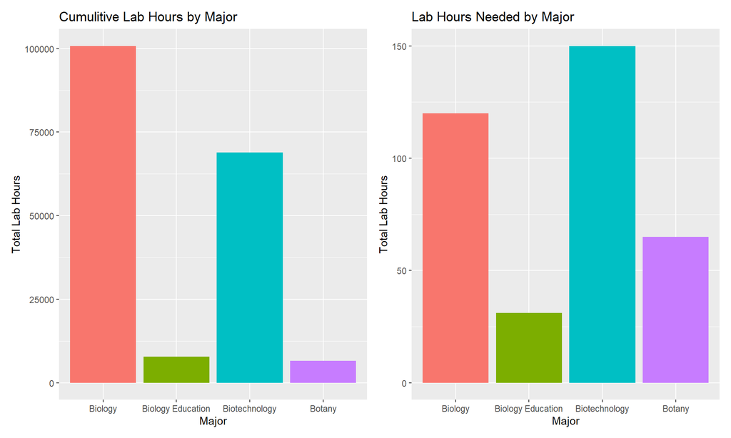

```r
(CUMULITIVE_LABHOURS | OVERALL_LABHOURS)
```

From this visualization we can see that biotechnology and biological education have the most and least required lab hours respectively.

# ACT and years to degree

The next thing that I wanted to analyze was if the highschool ACT score was correlated to how quickly students got their associates and bachelors degrees. So I made a new data set out of the larger one and then separated the ACT scores into ranges and found the average graduation time based on those ranges.

```r
df2<-cleaned_data_not_checked[, c("STUDENT_WAREHOUSE_ENTITY_UID","ACT_COMPOSITE","FIRST_YEAR","ASSOC_GRAD_YEAR","BACH_GRAD_YEAR","LAST_TERM_YEAR","LENGTH_OF_ENROLLMENT")]
df2$YEARS_TO_BACH <- df2$BACH_GRAD_YEAR - df2$FIRST_YEAR
df2$YEARS_TO_ASSOC <- df2$ASSOC_GRAD_YEAR - df2$FIRST_YEAR

df2$ACT_Range <- cut(df2$ACT_COMPOSITE,
                     breaks = c(-Inf, 0, 10, 15, 20, 24, 36, Inf),
                     labels = c("No_ACT", "0-10", "11-15", "16-20", "21-24", "25-36", "No_ACT"),
                     include.lowest = TRUE)
# Convert NAs to "NO_ACT"
df2$ACT_Range <- fct_na_value_to_level(df2$ACT_Range, "NO_ACT")
```

# Plot 2

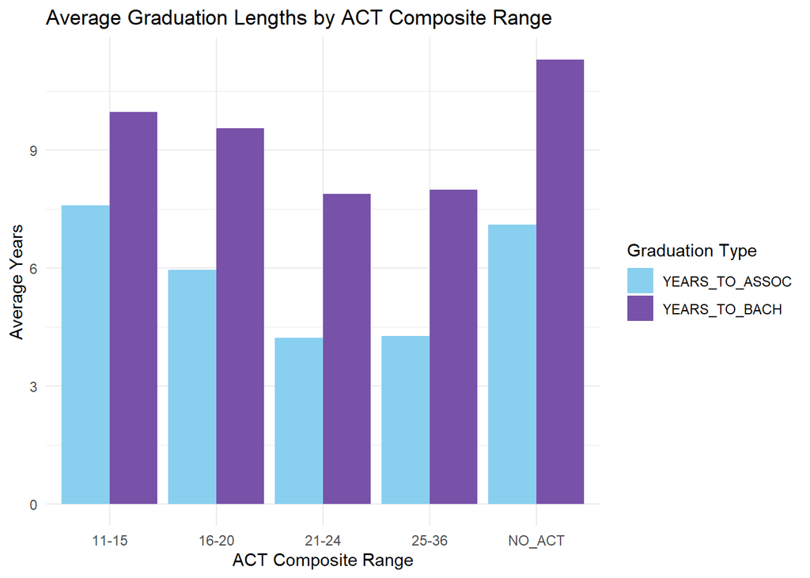

```r
# Create a new data frame with average values
summary_df <- aggregate(cbind(YEARS_TO_ASSOC, YEARS_TO_BACH) ~ ACT_Range, data = df2, FUN = mean)

# Reshape data for plotting
plot_data <- reshape2::melt(summary_df, id.vars = "ACT_Range")

# Plot grouped bar chart
ggplot(plot_data, aes(x = ACT_Range, y = value, fill = variable)) +
  geom_bar(stat = "identity", position = "dodge") +
  labs(title = "Average Graduation Lengths by ACT Composite Range",
       x = "ACT Composite Range",
       y = "Average Years") +
  scale_fill_manual(values = c("#89CFF0","#7851A9"), name = "Graduation Type") +
  theme_minimal()
```

# ACT to bach and assoc model

```r
#MODEL IF SIGNIFICANT act affect on grad time to assoc and then bach

assocmod <- glm(data=df2, formula = YEARS_TO_ASSOC ~ ACT_Range)
summary(assocmod)
```

```
##
## Call:
## glm(formula = YEARS_TO_ASSOC ~ ACT_Range, data = df2)
##
## Deviance Residuals:
##     Min       1Q   Median       3Q      Max
## -6.4402  -1.9289  -0.9289   1.3406  19.5598
##
## Coefficients:
##                 Estimate Std. Error t value Pr(>|t|)
## (Intercept)       6.3386     0.1403  45.180  < 2e-16 ***
## ACT_Range16-20   -0.4096     0.1465  -2.796  0.00518 **
## ACT_Range21-24   -1.6791     0.1445 -11.621  < 2e-16 ***
## ACT_Range25-36   -2.1215     0.1434 -14.796  < 2e-16 ***
## ACT_RangeNO_ACT   0.1017     0.1481   0.687  0.49220
## ---
## Signif. codes:  0 '***' 0.001 '**' 0.01 '*' 0.05 '.' 0.1 ' ' 1
##
## (Dispersion parameter for gaussian family taken to be 10.05776)
##
##     Null deviance: 330606  on 30575  degrees of freedom
## Residual deviance: 307476  on 30571  degrees of freedom
##   (612403 observations deleted due to missingness)
## AIC: 157358
##
## Number of Fisher Scoring iterations: 2
```

```r
bachmod <- glm(data=df2, formula = YEARS_TO_BACH ~ ACT_Range)
summary(bachmod)
```

```
##
## Call:
## glm(formula = YEARS_TO_BACH ~ ACT_Range, data = df2)
##
## Deviance Residuals:
##     Min       1Q   Median       3Q      Max
## -7.0758  -2.5687  -0.5687   1.9242  25.0902
##
## Coefficients:
##                 Estimate Std. Error t value Pr(>|t|)
## (Intercept)       5.0000     1.8098   2.763  0.00573 **
## ACT_Range11-15    4.0370     1.8162   2.223  0.02623 *
## ACT_Range16-20    3.0758     1.8102   1.699  0.08929 .
## ACT_Range21-24    1.9208     1.8100   1.061  0.28860
## ACT_Range25-36    1.5687     1.8100   0.867  0.38610
## ACT_RangeNO_ACT   0.9098     1.8100   0.503  0.61520
## ---
## Signif. codes:  0 '***' 0.001 '**' 0.01 '*' 0.05 '.' 0.1 ' ' 1
##
## (Dispersion parameter for gaussian family taken to be 13.10156)
##
##     Null deviance: 985211  on 72585  degrees of freedom
## Residual deviance: 950912  on 72580  degrees of freedom
##   (570393 observations deleted due to missingness)
## AIC: 392742
##
## Number of Fisher Scoring iterations: 2
```

This could also possibly show that those that didn’t take or weren’t able to take the ACT possibly have some confounding variables in their lives making it take longer to graduate. I wasn’t really able to find much connection though between the students that had no ACT score. There might be one but I couldn’t find it using the data in this set. It also appears that when it comes to students with higher ACT’s their score seems to be less significant than those with low scores. My conclusion is that lower ACT score students usually take longer in general to get their degree and those with higher scores vary more.

# Credits over Time

Next I wanted to try to visualize when students took large breaks from school so I looked at credits earned or passed linked to year or term for each student in a scatter in hopes to show plateau of when people leave for a while. I made another dataset but it still had too many values for me to manipulate and plot it so I took a random sample of the students and used that.

```r
#have to use previous filtered dataset so we can sort by majors
df3 <-majors_filtered[, c("STUDENT_WAREHOUSE_ENTITY_UID","ACADEMIC_PERIOD","TERM_TOTAL_CREDITS","CREDITS_PASSED","CREDITS_ATTEMPTED","CURRENT_MAJOR_NAME","GENDER_DESC")]

#Need to add term total credits as the the acedemic period increases for each student

# Convert ACADEMIC_PERIOD to a factor for proper ordering
df3$ACADEMIC_PERIOD <- factor(df3$ACADEMIC_PERIOD, levels = c("201320","201330","201340","201420","201430","201440","201520","201530","201540","201620","201630","201640",
                                                                          "201720","201730","201740","201820","201830","201840","201920","201930","201940","202020","202030","202040",
                                                                          "202120","202130"))

# Sort the data by ACADEMIC_PERIOD within each student
df3 <- df3[order( df3$ACADEMIC_PERIOD, df3$STUDENT_WAREHOUSE_ENTITY_UID), ]

# Calculate cumulative sum of TERM_TOTAL_CREDITS for each student
df3$Cumulative_Credits <- ave(df3$CREDITS_PASSED, df3$STUDENT_WAREHOUSE_ENTITY_UID, FUN = cumsum)

# Theres too many students fro the plot to generate so I want to radnomly select 500  students instead of all of them.
#225
set.seed(231)  # Set seed for reproducibility
sample_students <- sample(unique(df3$STUDENT_WAREHOUSE_ENTITY_UID), 500)
df_sample <- df3[df3$STUDENT_WAREHOUSE_ENTITY_UID %in% sample_students, ]
```

# Plot 3

Then I plotted it colored by major and faceted by gender.

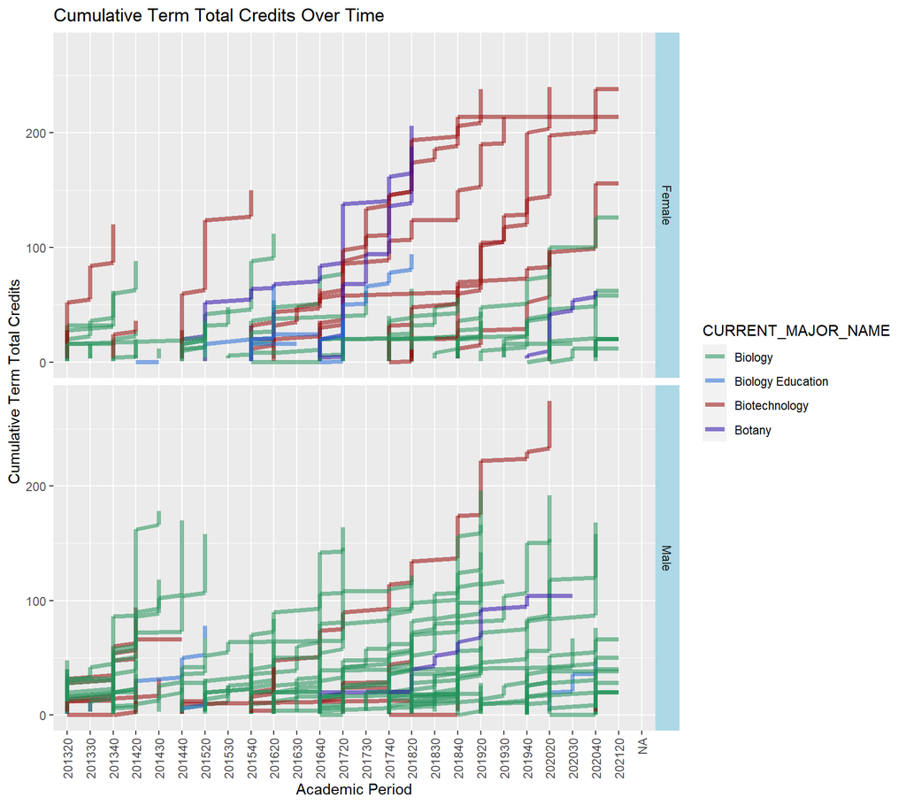

```r
# Create the plot

major_palette <- c("Biology" = "#23925A", "Biotechnology" = "#970A0A", "Biology Education" = "#256CD3", "Botany" = "#2F11AC")

# Plotting
ggplot(df_sample, aes(x = ACADEMIC_PERIOD, y = Cumulative_Credits, group = STUDENT_WAREHOUSE_ENTITY_UID)) +
  geom_line(aes(color = CURRENT_MAJOR_NAME), lwd = 1.5, alpha = 0.55) +
  scale_color_manual(values = major_palette) +  # Assign colors based on major
  facet_grid(GENDER_DESC ~ .) +  # Facet by gender
  labs(x = "Academic Period", y = "Cumulative Term Total Credits", title = "Cumulative Term Total Credits Over Time") +
  theme(
    legend.position = "right",  # Position the legend
    strip.text.x = element_text(size = 12, face = "bold"),
    strip.background = element_rect(fill = "lightblue"),
    axis.text.x = element_text(angle = 90, vjust = 0.5, hjust=1)
  )
```

From this graph we can firstly see there are more males enrolled than females, and see that the females take longer breaks more often possibly due to motherhood or other possible reasons.

# Prediction Models

After this I wanted to try to make a model that could predict whether or not someone would get their degree with as many relevant variables as R could handle.

I made one model with the variables seen in the code added together and one multiplied(with one added because it couldn’t handle them all multiplied). Compared them and then attempted to plot the predictions. Using the entire data set worth of rows.

```r
df <- cleaned_data_not_checked[c("DEGREE","ACT_COMPOSITE","FREEZE_OF_RECORD","FREEZE_TER","CURRENT_MAJOR_NAME","GENDER_DESC","PRIM_ETHNICITY_CATEGORY_DESC","BACH_GRAD_TERM","ASSOC_GRAD_TERM","TERM_TOTAL_CREDITS","FIRST_YEAR","LENGTH_OF_ENROLLMENT")]

#had to check levels to see whhich ones didnt have enough levels because I kept getting an error
library(MASS)

#overall model that predicts whether they'll graduate based off everything the model can think of using quasibinomial

mod_simple_subset <- glm(DEGREE ~ ACT_COMPOSITE + CURRENT_MAJOR_NAME + FREEZE_OF_RECORD + GENDER_DESC + PRIM_ETHNICITY_CATEGORY_DESC+ LENGTH_OF_ENROLLMENT,
                         data = df,
                         family = "binomial")

mod_complicated_subset <- glm(DEGREE ~  FREEZE_OF_RECORD * ACT_COMPOSITE * CURRENT_MAJOR_NAME + GENDER_DESC * PRIM_ETHNICITY_CATEGORY_DESC* LENGTH_OF_ENROLLMENT,
                         data = df,
                         family = "binomial")
#saveRDS(mod_complicated_subset, "./bigmodel.RDS")
#beepr::beep(sound=8)

compare_performance(mod_simple_subset,mod_complicated_subset)
```

```
## # Comparison of Model Performance Indices
##
## Name                   | Model |   AIC (weights) |  AICc (weights) |   BIC (weights) | Tjur's R2 |  RMSE | Sigma | Log_loss | Score_log |   PCP | Score_spherical
## -----------------------------------------------------------------------------------------------------------------------------------------------------------------
## mod_simple_subset      |   glm | 1.2e+05 (<.001) | 1.2e+05 (<.001) | 1.2e+05 (<.001) |     0.105 | 0.452 | 1.095 |    0.599 |      -Inf | 0.589 |
## mod_complicated_subset |   glm | 1.2e+05 (>.999) | 1.2e+05 (>.999) | 1.2e+05 (>.999) |     0.119 | 0.448 | 1.087 |    0.591 |      -Inf | 0.596 |       5.874e-05
```

```r
#made to check levels of the data set and print them out
#df_subset.asfactor <- df_subset %>%
#  mutate_at(vars("LENGTH_OF_ENROLLMENT","ACT_COMPOSITE","FREEZE_OF_RECORD","FREEZE_TER","CURRENT_MAJOR_NAME","GENDER_DESC","PRIM_ETHNICITY_CATEGORY_DESC","BACH_GRAD_TERM","ASSOC_GRAD_TERM","TERM_TOTAL_CREDITS","FIRST_YEAR"),
 #           as.factor)
#
#for (predictor in names(df_subset.asfactor)[categorical_predictors]) {
 # cat("Predictor:", predictor, "\n")
  #cat("Levels:", unique(df_subset.asfactor[[predictor]]), "\n\n")
#}


df_subset<-add_predictions(df,mod_complicated_subset,type='response')
```

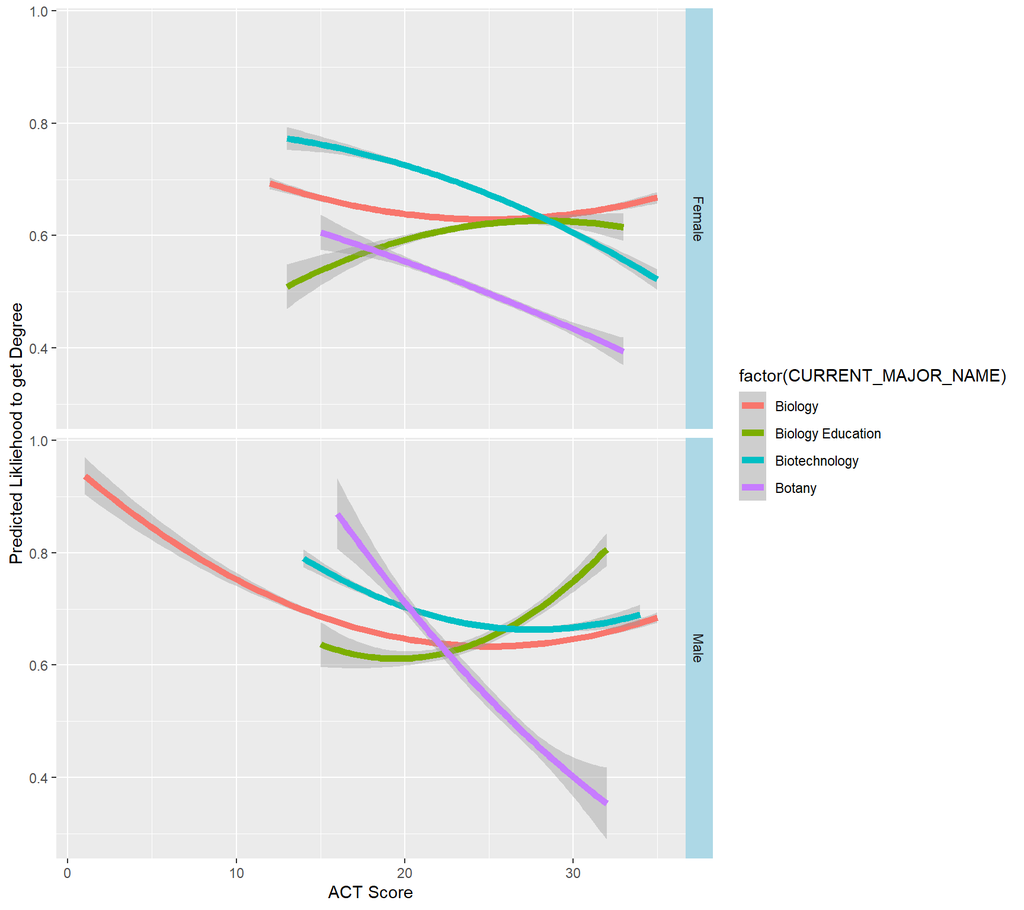

```r
df_subset %>%
  filter(!is.na(GENDER_DESC)) %>%
  ggplot(aes(x=ACT_COMPOSITE,y=pred,color=factor(CURRENT_MAJOR_NAME))) +
  geom_smooth(size = 2,method="lm",formula = y ~ poly(x,2))+
  facet_grid(GENDER_DESC ~ .)+
  labs(x = "ACT Score", y = "Predicted Likliehood to get Degree", title = NULL) +
  theme(
    legend.position = "right", # Position the legend
    strip.text.x = element_text(size = 12, face = "bold"),
    strip.background = element_rect(fill = "lightblue"))
```

This plot definitely subverted my expectations as most of the majors in male and female have a negative or almost no correlation with the ACT score. We can see though that almost no one in the whole dataset scored below 12 ACT other than some males with a biology major.

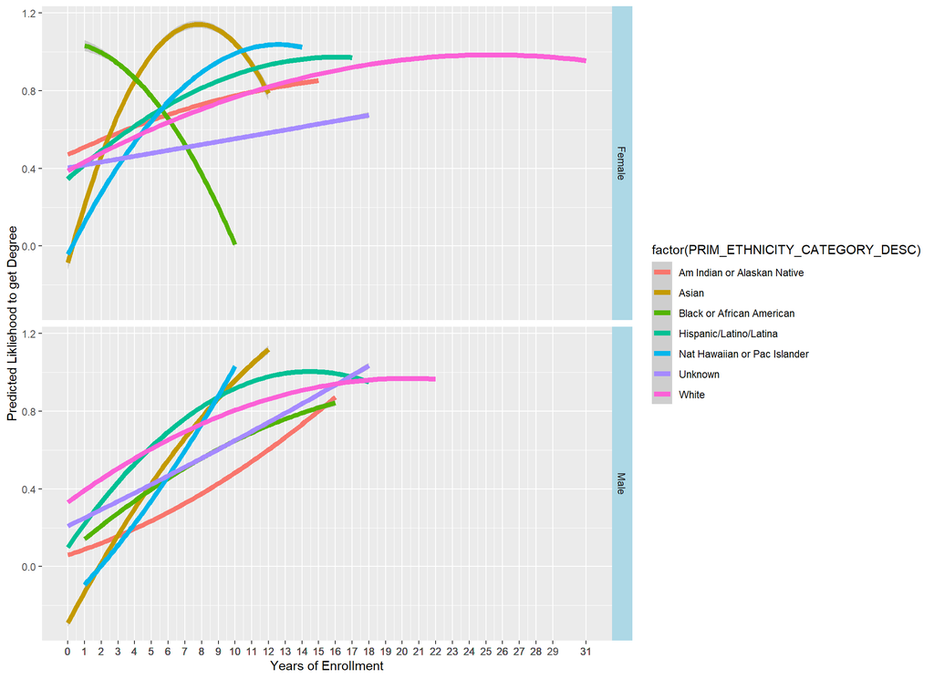

```r
df_subset %>%
  filter(!is.na(GENDER_DESC)) %>%
  ggplot(aes(x=LENGTH_OF_ENROLLMENT,y=pred,color=factor(PRIM_ETHNICITY_CATEGORY_DESC))) +
  geom_smooth(size = 2,method="lm",formula = y ~ poly(x,2))+
  facet_grid(GENDER_DESC ~ .)+
  labs(x = "Years of Enrollment", y = "Predicted Likliehood to get Degree", title = NULL)+
  theme(
    legend.position = "right", # Position the legend
    strip.text.x = element_text(size = 12, face = "bold"),
    strip.background = element_rect(fill = "lightblue"))+
  scale_x_continuous(breaks = df_subset$LENGTH_OF_ENROLLMENT, labels = df_subset$LENGTH_OF_ENROLLMENT)
```

The previous graph wasn’t really telling enough so I changed the variables to ethnicity and years of enrollment. From this we can see that most of the races (as expected) have an increase in graduation probability as years enrollment increases, except interestingly female African-Americans. From this dataset I’m not really able to tell why this is exactly. We can also see that whites often attend the longest and have a gradual increase of likelihood with their length of enrollment where as with other races such as female asian seem to have a drop off of likelihood after about 7-8 years of enrollment. Asians also have the peak likelihood of graduation for both genders.

# Discussion

Originally I wanted to analyze multiple colleges in Utah with certain variables but finding complete and consistent enough data to compare was basically impossible as the only website I could find that maybe had all the data had them in separate pdfs for each year. If I were to do a similar project it would be interesting to work with that data and look for differences across the colleges, especially comparing community colleges to more prestigious universities like UofU and BYU.

There may be other small correlations to find in this UVU data set but the amount of different variables and NAs in tidy format makes it difficult to spot potential connections.

# Conclusion

This project made me learn how to handle an extremely large dataset in different ways in order to get out certain parts and analyze them. I was originally going to use a new modelling of quasibinomial but my model seemed to work better with regular binomial modelling.